# Analyzing nominal responses using the multinomial-Poisson trick

Jacob O. Wobbrock

2025-01-24

## Introduction

This vignette shows how to use the `multpois` package for analyzing nominal response data. Nominal responses, sometimes called multinomial responses, are unordered categories. In certain experiments or surveys, the dependent variable can be one of *N* categories.

For example, let’s say we ask people what their favorite ice cream flavor is: vanilla, chocolate, or strawberry. This three-category response would be a *polytomous dependent variable*. Also, let’s say we wish to ask both adults and children about their favorite ice cream flavors to see if there is a difference by age group. We would then have a two-level between-subjects factor, *Age*. If we ask each respondent only once, this data set would represent a one-way between-subjects design. But perhaps we ask each participant once *each season*—in fall, winter, spring, and summer—to see if their responses vary by season. Now we would have a four-level within-subjects factor, *Season*, resulting in repeated measures, since each respondent would be asked four times.

The `multpois` package helps us analyze this type of data, where the dependent variable is nominal. It does so by modeling nominal responses as counts of category choices and uses mixed-effects Poisson regression to analyze these counts (Baker 1994, Chen & Kuo 2001). This technique is known as the multinomial-Poisson transformation (Guimaraes 2004) or trick (Lee et al. 2017).

R already provides options for the following situations:

- If the response is dichotomous, and the factors are only between-subjects, we can build a model using `glm` with `family=binomial` from the base `stats` package. The `Anova` function from the `car` package can be used to produce main effects and interactions. The `emmeans` function from the `emmeans` package can be used to produce *post hoc* pairwise comparisons.
- If the response is polytomous, and the factors are only between-subjects, we can build a model using `multinom` from the `nnet` package. The `Anova` function from the `car` package can be used to produce main effects and interactions. However, we cannot use the `emmeans` function from the `emmeans` package in the usual fashion. An approach to this issue by `emmeans` package author Russ Lenth is offered below.
- If the response is dichotomous, and one or more factors is within-subjects, we can build a model using `glmer` with `family=binomial` from the `lme4` package. The `Anova` function from the `car` package can be used to produce main effects and interactions. The `emmeans` function from the `emmeans` package can be used to produce *post hoc* pairwise comparisons.
- If the response is polytomous, and one or more factors is within-subjects, there is no easy option similar to the three above. The `multinom` function in `nnet` cannot accept random factors to handle repeated measures, and the `glmer` function in `lme4` does not offer a `family=multinomial` option. This package was created to address this case in particular, although it can address the above three cases, also.

The first four analyses below illustrate 2×2 designs having between- and within-subjects factors and dichotomous and polytomous responses. (The functions in `multpois` are not limited to 2×2 designs; any number of between- and within-subjects factors can be used.) The first three examples first use existing R solutions to which the results from `multpois` functions can be compared.

The fifth example returns to our ice cream scenario, above, and analyzes a mixed factorial design with one between-subjects factor (`Age`) and one within-subjects factor (`Season`).

## Contents

1. References: Relevant academic references for this vignette.
2. Libraries: External R libraries needed for this vignette.
3. Between-subjects 2×2 design with dichotomous response: Analysis of the `bs2` data set.
4. Between-subjects 2×2 design with polytomous response: Analysis of the `bs3` data set.
5. Within-subjects 2×2 design with dichotomous response: Analysis of the `ws2` data set.
6. Within-subjects 2×2 design with polytomous response: Analysis of the `ws3` data set.
7. Mixed factorial 2×2 design with polytomous response: Analysis of the `icecream` data set.

## References

Baker, S.G. (1994). The multinomial-Poisson transformation. *The Statistician 43* (4), pp. 495-504. https://doi.org/10.2307/2348134

Chen, Z. and Kuo, L. (2001). A note on the estimation of the multinomial logit model with random effects. *The American Statistician* 55 (2), pp. 89-95. https://www.jstor.org/stable/2685993

Guimaraes, P. (2004). Understanding the multinomial-Poisson transformation. *The Stata Journal* 4 (3), pp. 265-273. https://www.stata-journal.com/article.html?article=st0069

Lee, J.Y.L., Green, P.J.,and Ryan, L.M. (2017). On the “Poisson trick” and its extensions for fitting multinomial regression models. *arXiv preprint* available at https://doi.org/10.48550/arXiv.1707.08538

## Libraries

These are the libraries needed for running the code in this vignette:

```r
library(car)
library(nnet)
library(lme4)
library(lmerTest)
library(emmeans)
```

Let’s also load our library:

```r
library(multpois)
```

## Between-subjects 2×2 design with dichotomous response

Let’s load and prepare our first data set, a 2×2 between-subjects design with a dichotomous response. Factor `X1` has levels `{a, b}`, factor `X2` has levels `{c, d}`, and response `Y` has categories `{yes, no}`.

```r
data(bs2, package="multpois")
bs2$PId = factor(bs2$PId)
bs2$Y = factor(bs2$Y, levels=c("yes","no"))
bs2$X1 = factor(bs2$X1)
bs2$X2 = factor(bs2$X2)
contrasts(bs2$X1) <- "contr.sum"
contrasts(bs2$X2) <- "contr.sum"
```

Let’s visualize this data set using a mosaic plot:

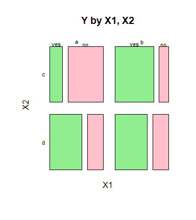

**Figure 1.** Proportions of `yes` (green) and `no` (pink) responses in four conditions: `{a, c}`, `{a, d}`, `{b, c}`, and `{b, d}`.

```r
xt = xtabs( ~ X1 + X2 + Y, data=bs2)
mosaicplot(xt, main="Y by X1, X2", las=1, col=c("lightgreen","pink"))
```

Given `X1` and `X2` are both between-subjects factors, and `Y` is a dichotomous response, we can analyze this data set using conventional logistic regression:

```r
m1 = glm(Y ~ X1*X2, data=bs2, family=binomial)
Anova(m1, type=3)
```

```
#> Analysis of Deviance Table (Type III tests)
#>
#> Response: Y
#>       LR Chisq Df Pr(>Chisq)
#> X1      4.4440  1    0.03502 *
#> X2      0.7513  1    0.38606
#> X1:X2   4.4440  1    0.03502 *
#> ---
#> Signif. codes:  0 '***' 0.001 '**' 0.01 '*' 0.05 '.' 0.1 ' ' 1
```

```r
emmeans(m1, pairwise ~ X1*X2, adjust="holm")$contrasts
```

```
#>  contrast  estimate    SE  df z.ratio p.value
#>  a c - b c    2.398 0.870 Inf   2.755  0.0352
#>  a c - a d    1.705 0.801 Inf   2.129  0.1661
#>  a c - b d    1.705 0.801 Inf   2.129  0.1661
#>  b c - a d   -0.693 0.847 Inf  -0.819  1.0000
#>  b c - b d   -0.693 0.847 Inf  -0.819  1.0000
#>  a d - b d    0.000 0.775 Inf   0.000  1.0000
#>
#> Results are given on the log odds ratio (not the response) scale.
#> P value adjustment: holm method for 6 tests
```

We can also analyze this data set using the multinomial-Poisson trick, which converts nominal responses to category counts and analyzes these counts using Poisson regression:

```r
m2 = glm.mp(Y ~ X1*X2, data=bs2)
Anova.mp(m2, type=3)
```

```
#> Analysis of Deviance Table (Type III tests)
#>
#> Response: Y
#> via the multinomial-Poisson trick
#>        Chisq Df  N Pr(>Chisq)
#> X1    4.4440  1 60    0.03502 *
#> X2    0.7513  1 60    0.38606
#> X1:X2 4.4440  1 60    0.03502 *
#> ---
#> Signif. codes:  0 '***' 0.001 '**' 0.01 '*' 0.05 '.' 0.1 ' ' 1
```

```r
glm.mp.con(m2, pairwise ~ X1*X2, adjust="holm")
```

```
#> $heading
#> [1] "Pairwise comparisons via the multinomial-Poisson trick"
#>
#> $contrasts
#>    Contrast    Chisq Df  N  p.value
#> 1 a.c - a.d 4.962518  1 30 0.129510
#> 2 a.c - b.c 9.045871  1 30 0.015798
#> 3 a.c - b.d 4.962518  1 30 0.129510
#> 4 a.d - b.c 0.687412  1 30 1.000000
#> 5 a.d - b.d 0.000000  1 30 1.000000
#> 6 b.c - b.d 0.687412  1 30 1.000000
#>
#> $notes
#> [1] "P value adjustment: holm method for 6 tests"
```

The omnibus results from logistic regression and from the multinomial-Poisson trick match, and the results from the *post hoc* pairwise comparisons are similar.

## Between-subjects 2×2 design with polytomous response

Let’s load and prepare our second data set, a 2×2 between-subjects design with a polytomous response. Factor `X1` has levels `{a, b}`, factor `X2` has levels `{c, d}`, and response `Y` has categories `{yes, no, maybe}`.

```r
data(bs3, package="multpois")
bs3$PId = factor(bs3$PId)
bs3$Y = factor(bs3$Y, levels=c("yes","no","maybe"))
bs3$X1 = factor(bs3$X1)
bs3$X2 = factor(bs3$X2)
contrasts(bs3$X1) <- "contr.sum"
contrasts(bs3$X2) <- "contr.sum"
```

Let’s again visualize the data using a mosaic plot:

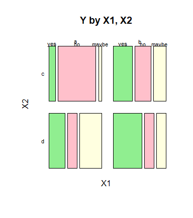

**Figure 2.** Proportions of `yes` (green), `no` (pink), and `maybe` (yellow) responses in four conditions: `{a, c}`, `{a, d}`, `{b, c}`, and `{b, d}`.

```r
xt = xtabs( ~ X1 + X2 + Y, data=bs3)
mosaicplot(xt, main="Y by X1, X2", las=1, col=c("lightgreen","pink","lightyellow"))
```

Given `X1` and `X2` are both between-subjects factors, and `Y` is a polytomous response, we might wish that `glm` had a `family=multinomial` option analogous to its `family=binomial` option, but it does not. Fortunately, we can analyze polytomous response data for (only) between-subjects factors using the `multinom` function from the `nnet` package:

```r
m3 = multinom(Y ~ X1*X2, data=bs3, trace=FALSE)
Anova(m3, type=3)
```

```
#> Analysis of Deviance Table (Type III tests)
#>
#> Response: Y
#>       LR Chisq Df Pr(>Chisq)
#> X1      3.5327  2    0.17096
#> X2      7.8081  2    0.02016 *
#> X1:X2   4.0039  2    0.13507
#> ---
#> Signif. codes:  0 '***' 0.001 '**' 0.01 '*' 0.05 '.' 0.1 ' ' 1
```

Unfortunately, `emmeans` does not work straightforwardly with `multinom` models. A solution to this issue from Russ Lenth, lead author of `emmeans`, was [posted on StackExchange](https://stackoverflow.com/questions/33316898/r-tukey-posthoc-tests-for-nnet-multinom-multinomial-fit-to-test-for-overall-dif):

```r
e0 = emmeans(m3, ~ X1*X2 | Y, mode="latent")
c0 = contrast(e0, method="pairwise", ref=1)
test(c0, joint=TRUE, by="contrast")
```

```
#>  contrast  df1 df2 F.ratio p.value note
#>  a c - b c   2   8   3.017  0.1056  d
#>  a c - a d   2   8   4.552  0.0479  d
#>  a c - b d   2   8   4.610  0.0466  d
#>  b c - a d   2   8   0.688  0.5298  d
#>  b c - b d   2   8   0.611  0.5661  d
#>  a d - b d   2   8   1.308  0.3224  d
#>
#> d: df1 reduced due to linear dependence
```

We can also analyze this data set using the multinomial-Poisson trick:

```r
m4 = glm.mp(Y ~ X1*X2, data=bs3)
Anova.mp(m4, type=3)
```

```
#> Analysis of Deviance Table (Type III tests)
#>
#> Response: Y
#> via the multinomial-Poisson trick
#>        Chisq Df  N Pr(>Chisq)
#> X1    3.5327  2 60    0.17096
#> X2    7.8081  2 60    0.02016 *
#> X1:X2 4.0039  2 60    0.13507
#> ---
#> Signif. codes:  0 '***' 0.001 '**' 0.01 '*' 0.05 '.' 0.1 ' ' 1
```

```r
glm.mp.con(m4, pairwise ~ X1*X2, adjust="holm")
```

```
#> $heading
#> [1] "Pairwise comparisons via the multinomial-Poisson trick"
#>
#> $contrasts
#>    Contrast     Chisq Df  N  p.value
#> 1 a.c - a.d 12.172660  2 30 0.013644
#> 2 a.c - b.c  6.990329  2 30 0.121376
#> 3 a.c - b.d 11.647010  2 30 0.014785
#> 4 a.d - b.c  1.425017  2 30 0.980826
#> 5 a.d - b.d  2.804595  2 30 0.738093
#> 6 b.c - b.d  1.252756  2 30 0.980826
#>
#> $notes
#> [1] "P value adjustment: holm method for 6 tests"
```

Again, the results from multinomial logistic regression and from the multinomial-Poisson trick match. The results from the *post hoc* pairwise comparisons are similar.

## Within-subjects 2×2 design with dichotomous response

Let’s load and prepare our third data set, a 2×2 within-subjects design with a dichotomous response. Factor `X1` has levels `{a, b}`, factor `X2` has levels `{c, d}`, and response `Y` has categories `{yes, no}`. Now the `PId` factor is repeated across rows, indicating participants were measured repeatedly.

```r
data(ws2, package="multpois")
ws2$PId = factor(ws2$PId)
ws2$Y = factor(ws2$Y, levels=c("yes","no"))
ws2$X1 = factor(ws2$X1)
ws2$X2 = factor(ws2$X2)
contrasts(ws2$X1) <- "contr.sum"
contrasts(ws2$X2) <- "contr.sum"
```

Let’s visualize this data set using a mosaic plot:

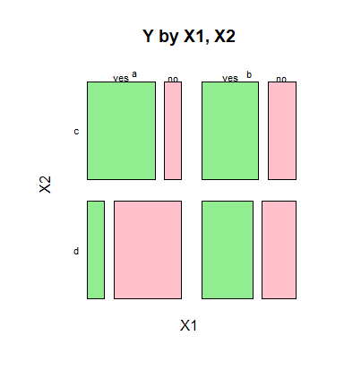

**Figure 3.** Proportions of `yes` (green) and `no` (pink) responses in four conditions: `{a, c}`, `{a, d}`, `{b, c}`, and `{b, d}`.

```r
xt = xtabs( ~ X1 + X2 + Y, data=ws2)
mosaicplot(xt, main="Y by X1, X2", las=1, col=c("lightgreen","pink"))
```

Given `X1` and `X2` are both within-subjects factors, and `Y` is a dichotomous response, we can analyze this using mixed-effects logistic regression. The function `glmer` from the `lme4` package provides this to us:

```r
m5 = glmer(Y ~ X1*X2 + (1|PId), data=ws2, family=binomial)
Anova(m5, type=3)
```

```
#> Analysis of Deviance Table (Type III Wald chisquare tests)
#>
#> Response: Y
#>              Chisq Df Pr(>Chisq)
#> (Intercept) 0.8553  1   0.355052
#> X1          0.8553  1   0.355052
#> X2          6.6368  1   0.009989 **
#> X1:X2       4.3758  1   0.036452 *
#> ---
#> Signif. codes:  0 '***' 0.001 '**' 0.01 '*' 0.05 '.' 0.1 ' ' 1
```

```r
emmeans(m5, pairwise ~ X1*X2, adjust="holm")$contrasts
```

```
#>  contrast  estimate    SE  df z.ratio p.value
#>  a c - b c   -0.693 0.847 Inf  -0.819  0.8258
#>  a c - a d   -2.773 0.913 Inf  -3.037  0.0143
#>  a c - b d   -0.981 0.833 Inf  -1.177  0.7176
#>  b c - a d   -2.079 0.847 Inf  -2.456  0.0702
#>  b c - b d   -0.288 0.760 Inf  -0.378  0.8258
#>  a d - b d    1.792 0.833 Inf   2.150  0.1262
#>
#> Results are given on the log odds ratio (not the response) scale.
#> P value adjustment: holm method for 6 tests
```

We can also analyze this data set using the multinomial-Poisson trick, now with an underlying mixed-effects Poisson regression model:

```r
m6 = glmer.mp(Y ~ X1*X2 + (1|PId), data=ws2)
Anova.mp(m6, type=3)
```

```
#> Analysis of Deviance Table (Type III Wald chisquare tests)
#>
#> Response: Y
#> via the multinomial-Poisson trick
#>        Chisq Df  N Pr(>Chisq)
#> X1    0.8553  1 60   0.355052
#> X2    6.6368  1 60   0.009989 **
#> X1:X2 4.3758  1 60   0.036452 *
#> ---
#> Signif. codes:  0 '***' 0.001 '**' 0.01 '*' 0.05 '.' 0.1 ' ' 1
```

```r
glmer.mp.con(m6, pairwise ~ X1*X2, adjust="holm")
```

```
#> $heading
#> [1] "Pairwise comparisons via the multinomial-Poisson trick"
#>
#> $contrasts
#>    Contrast    Chisq Df  N  p.value
#> 1 a.c - a.d 9.224701  1 30 0.014328
#> 2 a.c - b.c 0.670400  1 30 0.825824
#> 3 a.c - b.d 1.385304  1 30 0.717600
#> 4 a.d - b.c 6.033594  1 30 0.070180
#> 5 a.d - b.d 4.622979  1 30 0.126184
#> 6 b.c - b.d 0.143240  1 30 0.825824
#>
#> $notes
#> [1] "P value adjustment: holm method for 6 tests"
```

The results from mixed-effects logistic regression and results from the multinomial-Poisson trick match, including the results from the *post hoc* pairwise comparisons.

## Within-subjects 2×2 design with polytomous response

This fourth example illustrates the main reason that the `multpois` package was created. Unlike the three examples above, there are no straightforward options for analyzing nominal responses with repeated measures and obtaining ANOVA-style results. Some functions do offer mixed-effects multinomial regression modeling, such as `mblogit` in the `mclogit` package, but they do not enable ANOVA-style output. Other advanced methods exist, such as Markov Chain Monte Carlo (MCMC) methods in the `MCMCglmm` package, which does have a `family=multinomial` option, but these Bayesian methods are complex and deviate from the approaches illustrated above. Fortunately, we can again use the multinomial-Poisson trick.

Let’s load and prepare our fourth data set, a 2×2 within-subjects design with a polytomous response. Factor `X1` has levels `{a, b}`, factor `X2` has levels `{c, d}`, and response `Y` has categories `{yes, no, maybe}`. Again, the `PId` factor is repeated across rows, indicating participants were measured repeatedly.

```r
data(ws3, package="multpois")
ws3$PId = factor(ws3$PId)
ws3$Y = factor(ws3$Y, levels=c("yes","no","maybe"))
ws3$X1 = factor(ws3$X1)
ws3$X2 = factor(ws3$X2)
contrasts(ws3$X1) <- "contr.sum"
contrasts(ws3$X2) <- "contr.sum"
```

Let’s visualize this data set using a mosaic plot:

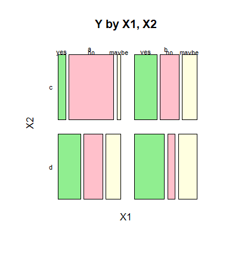

**Figure 4.** Proportions of `yes` (green), `no` (pink), and `maybe` (yellow) responses in four conditions: `{a, c}`, `{a, d}`, `{b, c}`, and `{b, d}`.

```r
xt = xtabs( ~ X1 + X2 + Y, data=ws3)
mosaicplot(xt, main="Y by X1, X2", las=1, col=c("lightgreen","pink","lightyellow"))
```

Because `multinom` from the `nnet` package cannot accept random factors, it cannot model repeated measures. And because `glmer` from the `lme4` package has no `family=multinomial` option, it cannot model polytomous responses. Fortunately, with the multinomial-Poisson trick, we can analyze polytomous responses from repeated measures:

```r
m7 = glmer.mp(Y ~ X1*X2 + (1|PId), data=ws3)
Anova.mp(m7, type=3)
```

```
#> Analysis of Deviance Table (Type III Wald chisquare tests)
#>
#> Response: Y
#> via the multinomial-Poisson trick
#>        Chisq Df  N Pr(>Chisq)
#> X1    6.6734  2 60    0.03555 *
#> X2    6.6713  2 60    0.03559 *
#> X1:X2 0.5514  2 60    0.75905
#> ---
#> Signif. codes:  0 '***' 0.001 '**' 0.01 '*' 0.05 '.' 0.1 ' ' 1
```

```r
glmer.mp.con(m7, pairwise ~ X1*X2, adjust="holm")
```

```
#> $heading
#> [1] "Pairwise comparisons via the multinomial-Poisson trick"
#>
#> $contrasts
#>    Contrast     Chisq Df  N  p.value
#> 1 a.c - a.d  6.033960  2 30 0.244735
#> 2 a.c - b.c  6.034054  2 30 0.244735
#> 3 a.c - b.d 10.676280  2 30 0.028830
#> 4 a.d - b.c  0.000000  2 30 1.000000
#> 5 a.d - b.d  1.590911  2 30 1.000000
#> 6 b.c - b.d  1.589577  2 30 1.000000
#>
#> $notes
#> [1] "P value adjustment: holm method for 6 tests"
```

## Mixed factorial 2×2 design with polytomous response

This fifth and final example is also the reason that the `multpois` package was created, since we have a polytomous response, one between-subjects factor, and one within-subjects factor. This mixed factorial design is also known as a split-plot design. (Note: Do not confuse mixed factorial designs with mixed-effects models. The former contain between- and within-subjects factors; the latter contain fixed and random effects.)

This fictional data is based on the scenario at the beginning of this vignette. Forty respondents, half adults and half children, were surveyed for their favorite ice cream four times, once per season. Thus, `Age` is a between-subjects factor with two levels `{adult, child}`, and `Season` is a within-subjects factor with four levels `{fall, winter, spring, summer}`. The polytomous response, `Pref`, has three categories: `{vanilla, chocolate, strawberry}`. The `PId` factor is repeated across rows, indicating respondents were queried four times each, once per season.

Let’s load and prepare this data set:

```r
data(icecream, package="multpois")
icecream$PId = factor(icecream$PId)
icecream$Pref = factor(icecream$Pref, levels=c("vanilla","chocolate","strawberry"))
icecream$Age = factor(icecream$Age, levels=c("adult","child"))
icecream$Season = factor(icecream$Season, levels=c("fall","winter","spring","summer"))
contrasts(icecream$Age) <- "contr.sum"
contrasts(icecream$Season) <- "contr.sum"
```

Let’s visualize this data set using a mosaic plot:

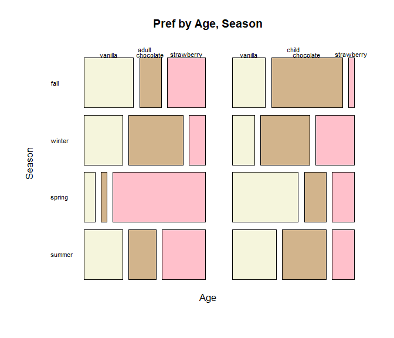

**Figure 5.** Proportions of `vanilla` (beige), `chocolate` (brown), and `strawberry` (pink) responses for adults and children across the four seasons.

```r
xt = xtabs( ~ Age + Season + Pref, data=icecream)
mosaicplot(xt, main="Pref by Age, Season", las=1, col=c("beige","tan","pink"))
```

As in the previous example, we can use the multinomial-Poisson trick to analyze repeated measures data with polytomous responses:

```r
m8 = glmer.mp(Pref ~ Age*Season + (1|PId), data=icecream)
Anova.mp(m8, type=3)
```

```
#> Analysis of Deviance Table (Type III Wald chisquare tests)
#>
#> Response: Pref
#> via the multinomial-Poisson trick
#>              Chisq Df   N Pr(>Chisq)
#> Age         8.8866  2 160   0.011757 *
#> Season     12.4627  6 160   0.052408 .
#> Age:Season 18.3213  6 160   0.005477 **
#> ---
#> Signif. codes:  0 '***' 0.001 '**' 0.01 '*' 0.05 '.' 0.1 ' ' 1
```

We have a main effect of `Age` and an `Age`×`Season` interaction but no main effect of `Season`. We can explore this further by graphically depicting response proportions in each age group:

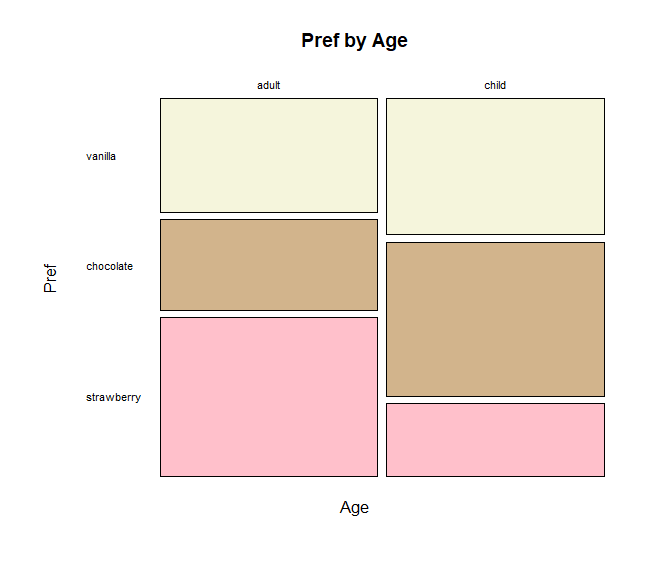

**Figure 6.** Proportions of `vanilla` (beige), `chocolate` (brown), and `strawberry` (pink) responses for adults and children. The main effect of `Age` emerges, with children preferring chocolate more and strawberry less than adults.

```r
xt = xtabs( ~ Age + Pref, data=icecream)
mosaicplot(xt, main="Pref by Age", las=1, col=c("beige","tan","pink"))
```

The different proportions by `Age` clearly emerge, explaining the main effect. Let’s also graphically depict the proportions by `Season`:

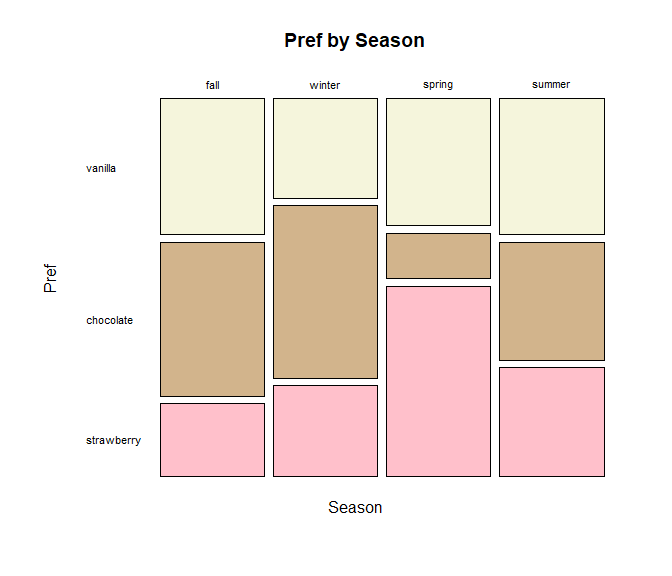

**Figure 7.** Proportions of `vanilla` (beige), `chocolate` (brown), and `strawberry` (pink) responses by `Season`. Although there are some differences in proportion, they are not quite statistically significant (*p* = 0.052).

```r
xt = xtabs( ~ Season + Pref, data=icecream)
mosaicplot(xt, main="Pref by Season", las=1, col=c("beige","tan","pink"))
```

Finally, we can again conduct *post hoc* pairwise comparisons. Note, however, there are many such possible comparisons, and best practice would require us to only conduct those comparisons driven by hypotheses or planned in advance. For example, we might wish to limit our pairwise comparisons to adults vs. children *within each season*, not across all seasons. In any case, we first conduct all pairwise comparisons just for illustration:

```r
glmer.mp.con(m8, pairwise ~ Age*Season, adjust="holm")
```

```
#> $heading
#> [1] "Pairwise comparisons via the multinomial-Poisson trick"
#>
#> $contrasts
#>                       Contrast     Chisq Df  N  p.value
#> 1    adult.fall - adult.spring  9.050067  2 40 0.260016
#> 2    adult.fall - adult.summer  0.425876  2 40 1.000000
#> 3    adult.fall - adult.winter  4.153318  2 40 1.000000
#> 4      adult.fall - child.fall  8.128467  2 40 0.377872
#> 5    adult.fall - child.spring  1.222476  2 40 1.000000
#> 6    adult.fall - child.summer  2.136531  2 40 1.000000
#> 7    adult.fall - child.winter  3.642132  2 40 1.000000
#> 8  adult.spring - adult.summer  7.611634  2 40 0.447111
#> 9  adult.spring - adult.winter 14.903020  2 40 0.015820
#> 10   adult.spring - child.fall 14.957280  2 40 0.015820
```

[output cut: 21 more lines]

If we wished to compare adults vs. children in each season (fall, winter, spring, and summer), we would first conduct all pairwise comparisons, leaving them *uncorrected* for multiple comparisons…

```r
glmer.mp.con(m8, pairwise ~ Age*Season, adjust="none")
```

```
#> $heading
#> [1] "Pairwise comparisons via the multinomial-Poisson trick"
#>
#> $contrasts
#>                       Contrast     Chisq Df  N  p.value
#> 1    adult.fall - adult.spring  9.050067  2 40 0.010834
#> 2    adult.fall - adult.summer  0.425876  2 40 0.808206
#> 3    adult.fall - adult.winter  4.153318  2 40 0.125348
#> 4      adult.fall - child.fall  8.128467  2 40 0.017176
#> 5    adult.fall - child.spring  1.222476  2 40 0.542679
#> 6    adult.fall - child.summer  2.136531  2 40 0.343604
#> 7    adult.fall - child.winter  3.642132  2 40 0.161853
#> 8  adult.spring - adult.summer  7.611634  2 40 0.022241
#> 9  adult.spring - adult.winter 14.903020  2 40 0.000581
#> 10   adult.spring - child.fall 14.957280  2 40 0.000565
```

[output cut: 21 more lines]

…and then we would extract the relevant comparisons (rows 4, 22, 11, and 17, respectively), and manually correct their *p*-values to guard against Type I errors, like so:

```r
p.adjust(c(0.017176, 0.308026, 0.001020, 0.363038), method="holm")
```

```
#> [1] 0.051528 0.616052 0.004080 0.616052
```

Thus, after correction using Holm’s sequential Bonferroni procedure [(Holm 1979)](https://www.jstor.org/stable/4615733), we see that adults vs. children in **spring** are significantly different (*p* < .05). Looking again at Figure 5 visually confirms this result.

Copyright (C) 2024-2025 Jacob O. Wobbrock <wobbrock@uw.edu>